# Untitled

2023-04-17

```r
library(tidyverse)
```

Create a custom colour palette

```r
col_scheme <- c("#E89FE9", "#50434F", "#B6A7B5", "#F9A472", "#BD7040")
col_scheme
```

```
## [1] "#E89FE9" "#50434F" "#B6A7B5" "#F9A472" "#BD7040"
```

Read in data

```r
qb_competitors <- CodeClanData::qb_competitors
qb_monthly_sales <- CodeClanData::qb_monthly_sales
qb_revenue_breakdown <- CodeClanData::qb_revenue_breakdown
qb_device_data <- CodeClanData::qb_device_data
```

Q1: Take the data in the dataset qb_revenue_breakdown and make a stacked bar chart showing the sources of revenue across the two years in the dataset.

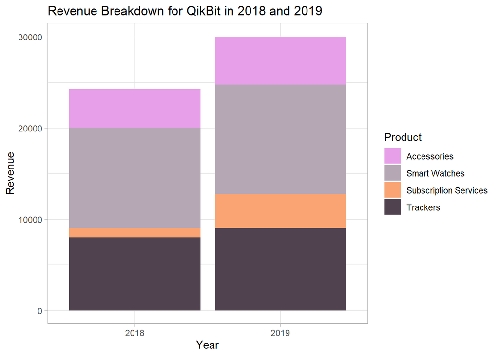

```r
qb_revenue_breakdown %>%
  ggplot()+
  geom_bar(aes(x = Year, y = Revenue, fill = Product), stat = "identity")+
  labs(
    x = "Year",
    y = "Revenue",
    title = "Revenue Breakdown for QikBit in 2018 and 2019")+
  scale_fill_manual(
    values = c(
      "Accessories" = "#E89FE9",
      "Smart Watches" = "#B6A7B5",
      "Subscription Services" = "#F9A472",
      "Trackers" = "#50434F")
  )+
  theme_light()
```

#Q2: Make a line chart showing monthly sales of the “flagship product” - the ‘KwikBit Unit 1’ - over the last year. This data is inside qb_monthly_sales, but you will need to use filter() or subset() (base R).

```r
KwikBit_unit1 <- qb_monthly_sales %>%
  filter(Cashflow == "Kwikbit Unit 1 Sales")
```

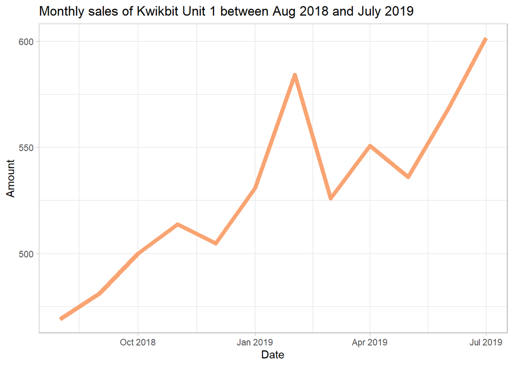

```r
ggplot(KwikBit_unit1)+
  geom_line(aes(x = Date, y = Amount), colour = "#F9A472", size = 2)+
  labs(
    x = "Date",
    y = "Amount",
    title = "Monthly sales of Kwikbit Unit 1 between Aug 2018 and July 2019")+
  theme_light()
```

Q3: Make a line chart showing monthly revenue and costs over the last year. This data is also in qb_monthly_sales.

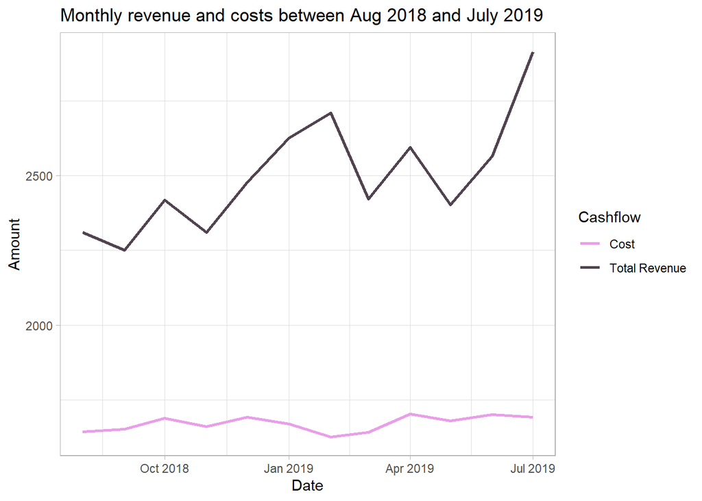

```r
qb_monthly_sales %>%
  filter(Cashflow != "Kwikbit Unit 1 Sales") %>%
  ggplot()+
  geom_line(aes(x = Date, y = Amount, group = Cashflow, colour = Cashflow), size = 1)+
  labs(
    x = "Date",
    y = "Amount",
    title = "Monthly revenue and costs between Aug 2018 and July 2019")+
  scale_colour_manual(values = c(col_scheme))+
  theme_light()
```

Q4:Show annual sales of personal fitness trackers over the last 5 years broken down by company as a ribbon plot (use geom_area). This data is in qb_competitors.

```r
qb_competitors <- qb_competitors %>%
  mutate(Revenue_thousands = Revenue / 1000)
```

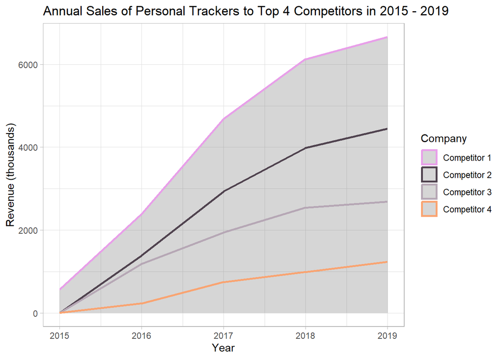

```r
qb_competitors %>%
  ggplot()+
  geom_area(aes(x = Year, y = Revenue_thousands, group = Company, colour = Company), size = 1, alpha = 0.2)+
  labs(
    x = "Year",
    y = "Revenue (thousands)",
    title = "Annual Sales of Personal Trackers to Top 4 Competitors in 2015 - 2019"
  )+
  scale_colour_manual(values = c(col_scheme))+
  theme_light()
```

Q5:Now show the sales from the four competitors as a line graph. Include an extra layer that shows the data points used to make the lines.

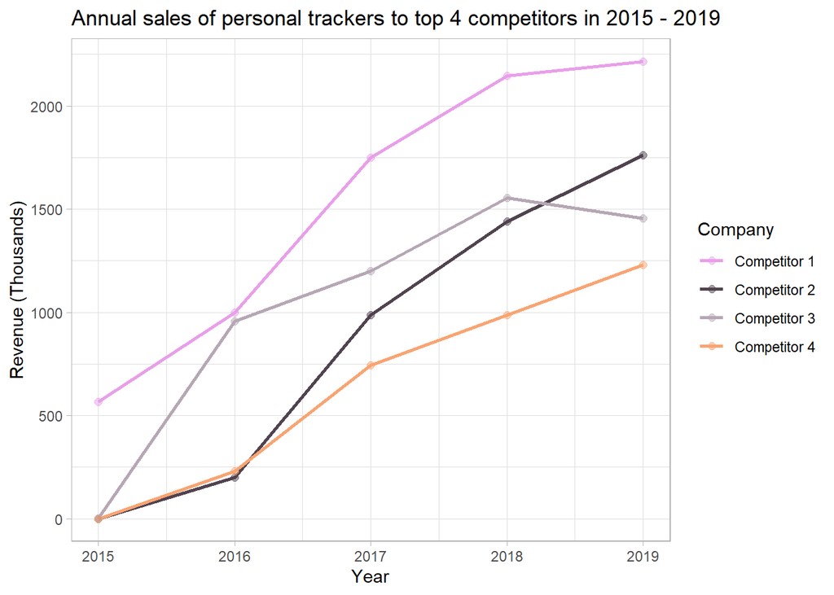

```r
  ggplot(qb_competitors)+
  aes(x = Year, y = Revenue_thousands, group = Company, colour = Company)+
  geom_line(aes(group = Company), size = 1)+
  geom_point(alpha = 0.5, size = 2)+
  labs(
    x = "Year",
    y = "Revenue (Thousands)",
    title = "Annual sales of personal trackers to top 4 competitors in 2015 - 2019")+
  scale_colour_manual(values = c(col_scheme))+
  theme_light()
```

Q6: Now the company wants to compare the number of steps that their device counts vs. their competitors. Make a line graph of the number of steps throughout time, and use faceting to compare between companies and people. The data for this is in qb_device_data.

```r
device_grouped <- qb_device_data %>%
  group_by(device, id, hours) %>%
  summarise(total_steps_per_hour= sum(counts))
head(device_grouped)
```

```
## # A tibble: 6 × 4
## # Groups:   device, id [1]
##   device  id      hours total_steps_per_hour
##   <fct>   <fct>   <dbl>                <dbl>
## 1 qikbit1 person1     6                  189
## 2 qikbit1 person1     7                 1777
## 3 qikbit1 person1     8                 1512
## 4 qikbit1 person1     9                  724
## 5 qikbit1 person1    10                 3468
## 6 qikbit1 person1    11                10407
```

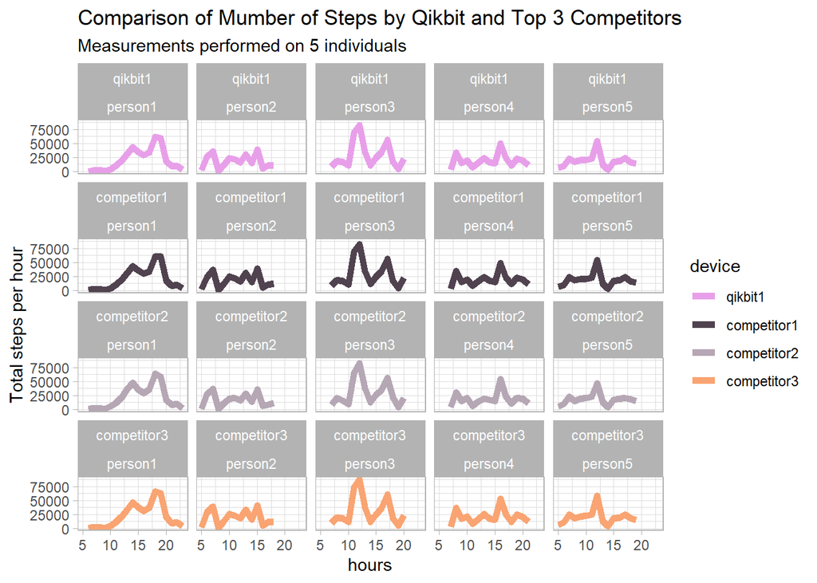

```r
device_grouped%>%
  ggplot(aes(x = hours, y = total_steps_per_hour, group = id, colour = device))+
  geom_line(size = 2)+
  facet_wrap(device ~ id )+
  scale_colour_manual(values = c(col_scheme))+
  theme_light()+
  labs(
    y = "Total steps per hour",
    title = "Comparison of Mumber of Steps by Qikbit and Top 3 Competitors",
    subtitle = "Measurements performed on 5 individuals"
  )
```

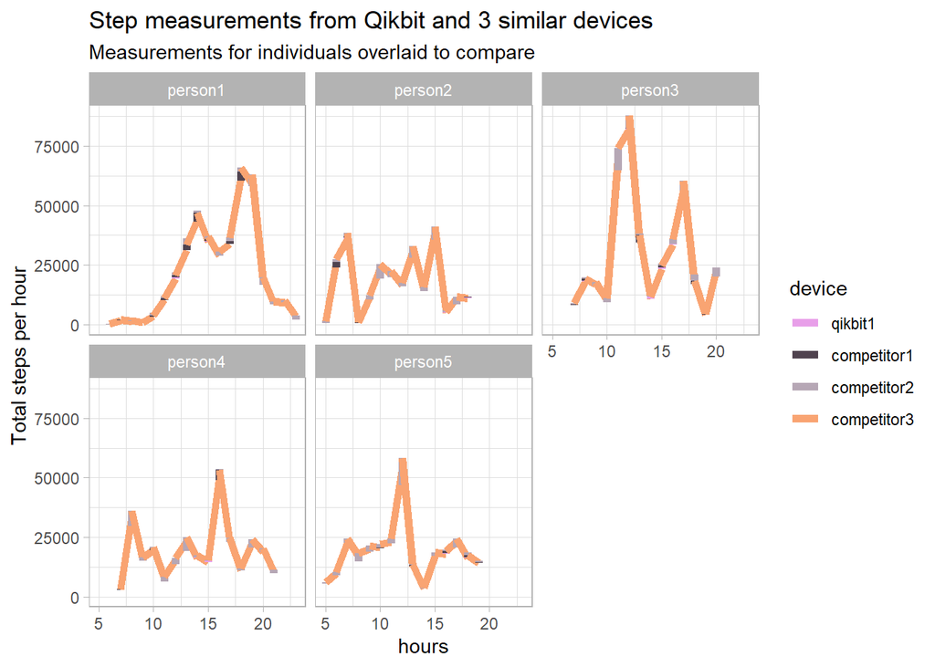

```r
device_grouped%>%
  ggplot(aes(x = hours, y = total_steps_per_hour, group = id, colour = device))+
  geom_line(size = 2)+
  scale_colour_manual(values = c(col_scheme))+
  facet_wrap(~ id )+
  theme_light()+
  labs(
    y = "Total steps per hour",
    title = "Step measurements from Qikbit and 3 similar devices",
    subtitle = "Measurements for individuals overlaid to compare")
```